# Day8Exercise

Nicholas Nigro

9/15/2020

# Exercise 8

I know the markdown is messy, but I was trying to focus mostly on the code rather than the formatting. I will keep in mind formatting in future projects.

## 1. Load data

```r
schools <- read.csv(here::here("data/nys_schools.csv"), stringsAsFactors=FALSE)
counties <- read.csv(here::here("data/nys_acs.csv"), stringsAsFactors=FALSE)
```

## 2. Exploring Data

```r
#quick look at the structure of each dataset
head(schools)
```

```
##     school_cd              school_name               district_name county_name
## 1 10100010014 MONTESSORI MAGNET SCHOOL ALBANY CITY SCHOOL DISTRICT      ALBANY
## 2 10100010014 MONTESSORI MAGNET SCHOOL ALBANY CITY SCHOOL DISTRICT      ALBANY
## 3 10100010014 MONTESSORI MAGNET SCHOOL ALBANY CITY SCHOOL DISTRICT      ALBANY
## 4 10100010014 MONTESSORI MAGNET SCHOOL ALBANY CITY SCHOOL DISTRICT      ALBANY
## 5 10100010014 MONTESSORI MAGNET SCHOOL ALBANY CITY SCHOOL DISTRICT      ALBANY
## 6 10100010014 MONTESSORI MAGNET SCHOOL ALBANY CITY SCHOOL DISTRICT      ALBANY
##             region year total_enroll per_free_lunch per_reduced_lunch per_lep
## 1 CAPITAL DISTRICT 2008          316           0.33              0.10    0.01
## 2 CAPITAL DISTRICT 2009          312           0.32              0.08    0.02
## 3 CAPITAL DISTRICT 2010          300           0.26              0.08    0.03
## 4 CAPITAL DISTRICT 2011          326           0.22              0.07    0.03
## 5 CAPITAL DISTRICT 2012          294           0.31              0.06    0.03
## 6 CAPITAL DISTRICT 2013          321           0.25              0.08    0.03
##   mean_ela_score mean_math_score
## 1       658.0000        669.6667
## 2       672.6667        678.6667
## 3       670.3333        683.0000
## 4       666.6667        681.3333
## 5       670.3333        687.3333
## 6       309.6667        311.0000
```

```r
head(counties)
```

```
##   county_name year county_per_poverty median_household_income county_per_bach
## 1      ALBANY 2009          0.1183511                   55350       0.1903682
## 2      ALBANY 2010          0.1194052                   56090       0.1971886
## 3      ALBANY 2011          0.1207243                   57715       0.1989826
## 4      ALBANY 2012          0.1237525                   59359       0.1975504
## 5      ALBANY 2013          0.1229728                   59394       0.2045352
## 6      ALBANY 2014          0.1286178                   59940       0.2011998
```

```r
#see the number of rows and columns we have total
dim(schools)
```

```
## [1] 35663    12
```

```r
dim(counties)
```

```
## [1] 496   5
```

```r
#see all column data types
str(schools)
```

```
## 'data.frame':    35663 obs. of  12 variables:
##  $ school_cd        : num  1.01e+10 1.01e+10 1.01e+10 1.01e+10 1.01e+10 ...
##  $ school_name      : chr  "MONTESSORI MAGNET SCHOOL" "MONTESSORI MAGNET SCHOOL" "MONTESSORI MAGNET SCHOOL" "MONTESSORI MAGNET SCHOOL" ...
##  $ district_name    : chr  "ALBANY CITY SCHOOL DISTRICT" "ALBANY CITY SCHOOL DISTRICT" "ALBANY CITY SCHOOL DISTRICT" "ALBANY CITY SCHOOL DISTRICT" ...
##  $ county_name      : chr  "ALBANY" "ALBANY" "ALBANY" "ALBANY" ...
##  $ region           : chr  "CAPITAL DISTRICT" "CAPITAL DISTRICT" "CAPITAL DISTRICT" "CAPITAL DISTRICT" ...
##  $ year             : int  2008 2009 2010 2011 2012 2013 2014 2015 2016 2017 ...
##  $ total_enroll     : num  316 312 300 326 294 321 335 347 366 359 ...
##  $ per_free_lunch   : num  0.33 0.32 0.26 0.22 0.31 0.25 0.35 0.22 0.29 0.26 ...
##  $ per_reduced_lunch: num  0.1 0.08 0.08 0.07 0.06 0.08 0.04 0 0.02 0.01 ...
##  $ per_lep          : num  0.01 0.02 0.03 0.03 0.03 0.03 0.06 0.06 0.05 0.07 ...
##  $ mean_ela_score   : num  658 673 670 667 670 ...
##  $ mean_math_score  : num  670 679 683 681 687 ...
```

```r
str(counties)
```

```
## 'data.frame':    496 obs. of  5 variables:
##  $ county_name            : chr  "ALBANY" "ALBANY" "ALBANY" "ALBANY" ...
##  $ year                   : int  2009 2010 2011 2012 2013 2014 2015 2016 2009 2010 ...
##  $ county_per_poverty     : num  0.118 0.119 0.121 0.124 0.123 ...
##  $ median_household_income: int  55350 56090 57715 59359 59394 59940 59887 60904 40917 41305 ...
##  $ county_per_bach        : num  0.19 0.197 0.199 0.198 0.205 ...
```

```r
#see descriptive statistics
summary(schools)
```

```
##    school_cd         school_name        district_name      county_name
##  Min.   :1.010e+10   Length:35663       Length:35663       Length:35663
##  1st Qu.:2.802e+11   Class :character   Class :character   Class :character
##  Median :3.317e+11   Mode  :character   Mode  :character   Mode  :character
##  Mean   :3.568e+11
##  3rd Qu.:4.725e+11
##  Max.   :6.808e+11
##     region               year       total_enroll    per_free_lunch
##  Length:35663       Min.   :2008   Min.   : -99.0   Min.   :-99.0000
##  Class :character   1st Qu.:2010   1st Qu.: 339.0   1st Qu.:  0.1900
##  Mode  :character   Median :2013   Median : 469.0   Median :  0.4200
##                     Mean   :2013   Mean   : 523.6   Mean   :  0.4188
##                     3rd Qu.:2015   3rd Qu.: 648.0   3rd Qu.:  0.7200
##                     Max.   :2017   Max.   :2347.0   Max.   :257.0000
##  per_reduced_lunch      per_lep          mean_ela_score  mean_math_score
##  Min.   :-99.00000   Min.   :-99.00000   Min.   :-99.0   Min.   :-99.0
##  1st Qu.:  0.03000   1st Qu.:  0.00000   1st Qu.:296.0   1st Qu.:298.0
##  Median :  0.06000   Median :  0.03000   Median :324.2   Median :330.8
##  Mean   :  0.02852   Mean   :  0.04124   Mean   :447.1   Mean   :456.0
##  3rd Qu.:  0.10000   3rd Qu.:  0.11000   3rd Qu.:666.3   3rd Qu.:683.5
##  Max.   : 53.00000   Max.   :  1.00000   Max.   :720.8   Max.   :738.7
```

```r
summary(counties)
```

```
##  county_name             year      county_per_poverty median_household_income
##  Length:496         Min.   :2009   Min.   :0.04689    Min.   : 33794
##  Class :character   1st Qu.:2011   1st Qu.:0.10903    1st Qu.: 46347
##  Mode  :character   Median :2012   Median :0.12884    Median : 50135
##                     Mean   :2012   Mean   :0.13085    Mean   : 54116
##                     3rd Qu.:2014   3rd Qu.:0.14929    3rd Qu.: 56448
##                     Max.   :2016   Max.   :0.29935    Max.   :102044
##  county_per_bach
##  Min.   :0.07574
##  1st Qu.:0.11018
##  Median :0.13169
##  Mean   :0.14410
##  3rd Qu.:0.17431
##  Max.   :0.31795
```

It also seems there’s a wide variety of sizes on enrolled students and mean math scores across the different schools. Percentage of students qualifying for free lunch is much higher across the board that students qualifying for reduced price lunch. County statistics vary widely as well.

## 3. Recoding Data

```r
#remove rows with missing values
schools = schools[schools$total_enroll != -99,]
schools = schools[schools$mean_ela_score != -99,]
schools = schools[schools$mean_math_score != -99,]
summary(schools)
```

```
##    school_cd         school_name        district_name      county_name
##  Min.   :1.010e+10   Length:33444       Length:33444       Length:33444
##  1st Qu.:2.802e+11   Class :character   Class :character   Class :character
##  Median :3.317e+11   Mode  :character   Mode  :character   Mode  :character
##  Mean   :3.547e+11
##  3rd Qu.:4.618e+11
##  Max.   :6.808e+11
##     region               year       total_enroll    per_free_lunch
##  Length:33444       Min.   :2008   Min.   :  13.0   Min.   :0.0000
##  Class :character   1st Qu.:2010   1st Qu.: 348.0   1st Qu.:0.1900
##  Mode  :character   Median :2013   Median : 477.0   Median :0.4200
##                     Mean   :2013   Mean   : 535.7   Mean   :0.4557
##                     3rd Qu.:2015   3rd Qu.: 660.0   3rd Qu.:0.7300
##                     Max.   :2017   Max.   :2347.0   Max.   :1.8300
##  per_reduced_lunch    per_lep       mean_ela_score  mean_math_score
##  Min.   :0.00000   Min.   :0.0000   Min.   :195.0   Min.   :213.0
##  1st Qu.:0.03000   1st Qu.:0.0000   1st Qu.:300.0   1st Qu.:303.0
##  Median :0.06000   Median :0.0300   Median :347.5   Median :361.0
##  Mean   :0.06904   Mean   :0.0757   Mean   :483.2   Mean   :492.7
##  3rd Qu.:0.10000   3rd Qu.:0.1100   3rd Qu.:667.3   3rd Qu.:684.7
##  Max.   :0.91000   Max.   :1.0000   Max.   :720.8   Max.   :738.7
```

```r
#create data tables
library(data.table)
schools_dt <- data.table(schools)
counties_dt <- data.table(counties)

#create poverty group column using quartiles
counties_dt[, poverty_level := ifelse(county_per_poverty <= .10903, "Low",
                                ifelse(county_per_poverty <= .14929, "Medium",
                                ifelse(county_per_poverty > .14929, "High", NA)))]

head(counties_dt)
```

```
##    county_name year county_per_poverty median_household_income county_per_bach
## 1:      ALBANY 2009          0.1183511                   55350       0.1903682
## 2:      ALBANY 2010          0.1194052                   56090       0.1971886
## 3:      ALBANY 2011          0.1207243                   57715       0.1989826
## 4:      ALBANY 2012          0.1237525                   59359       0.1975504
## 5:      ALBANY 2013          0.1229728                   59394       0.2045352
## 6:      ALBANY 2014          0.1286178                   59940       0.2011998
##    poverty_level
## 1:        Medium
## 2:        Medium
## 3:        Medium
## 4:        Medium
## 5:        Medium
## 6:        Medium
```

```r
str(counties_dt)
```

```
## Classes 'data.table' and 'data.frame':   496 obs. of  6 variables:
##  $ county_name            : chr  "ALBANY" "ALBANY" "ALBANY" "ALBANY" ...
##  $ year                   : int  2009 2010 2011 2012 2013 2014 2015 2016 2009 2010 ...
##  $ county_per_poverty     : num  0.118 0.119 0.121 0.124 0.123 ...
##  $ median_household_income: int  55350 56090 57715 59359 59394 59940 59887 60904 40917 41305 ...
##  $ county_per_bach        : num  0.19 0.197 0.199 0.198 0.205 ...
##  $ poverty_level          : chr  "Medium" "Medium" "Medium" "Medium" ...
##  - attr(*, ".internal.selfref")=<externalptr>
```

```r
#Scale math and reading scores within each year for all schools
schools_dt[, scaled_ela_score := scale(mean_ela_score), by=c("county_name", "year")]
schools_dt[, scaled_math_score := scale(mean_math_score), by=c("county_name", "year")]
```

A categorical poverty variable was created for each country where the bottom quartile of counties in percent poverty were considered to have a “Low” poverty level, the middle two quartiles were considered “Medium”, and the highest quartile considered “High” poverty counties.

## 4. Merge Datasets

```r
#group schools at the county level and get a rough estimate of county aggregations
group_schools <- schools_dt[, .(sum(total_enroll), median(per_free_lunch), median(per_reduced_lunch), median(per_lep), median(scaled_ela_score), median(scaled_math_score)), by = c("county_name", "year")]
setnames(group_schools, c("county_name", "year", "total_enrolled", "median_per_free_lunch", "median_per_reduced_lunch", "median_per_lep", "median_ela_score", "median_math_score"))
head(group_schools)
```

```
##    county_name year total_enrolled median_per_free_lunch
## 1:      ALBANY 2008          22989                 0.295
## 2:      ALBANY 2009          25629                 0.230
## 3:      ALBANY 2010          26620                 0.235
## 4:      ALBANY 2011          26316                 0.240
## 5:      ALBANY 2012          25572                 0.310
## 6:      ALBANY 2013          25688                 0.295
##    median_per_reduced_lunch median_per_lep median_ela_score median_math_score
## 1:                     0.08           0.01      -0.01412641         0.1388654
## 2:                     0.08           0.02       0.12656263         0.1072526
## 3:                     0.07           0.02       0.11055753         0.1648598
## 4:                     0.06           0.02       0.08430934         0.1168304
## 5:                     0.06           0.02       0.04582039         0.1350470
## 6:                     0.07           0.02       0.01241172         0.2127996
```

```r
#merge county and school information into one dataset
merged_dt = group_schools[counties_dt, on = c("county_name", "year")]
head(merged_dt)
```

```
##    county_name year total_enrolled median_per_free_lunch
## 1:      ALBANY 2009          25629                 0.230
## 2:      ALBANY 2010          26620                 0.235
## 3:      ALBANY 2011          26316                 0.240
## 4:      ALBANY 2012          25572                 0.310
## 5:      ALBANY 2013          25688                 0.295
## 6:      ALBANY 2014          25663                 0.300
##    median_per_reduced_lunch median_per_lep median_ela_score median_math_score
## 1:                     0.08           0.02       0.12656263         0.1072526
## 2:                     0.07           0.02       0.11055753         0.1648598
## 3:                     0.06           0.02       0.08430934         0.1168304
## 4:                     0.06           0.02       0.04582039         0.1350470
## 5:                     0.07           0.02       0.01241172         0.2127996
## 6:                     0.04           0.03       0.13363412         0.3301215
##    county_per_poverty median_household_income county_per_bach poverty_level
## 1:          0.1183511                   55350       0.1903682        Medium
## 2:          0.1194052                   56090       0.1971886        Medium
## 3:          0.1207243                   57715       0.1989826        Medium
## 4:          0.1237525                   59359       0.1975504        Medium
## 5:          0.1229728                   59394       0.2045352        Medium
## 6:          0.1286178                   59940       0.2011998        Medium
```

## 5. Create Summary Tables

```r
#create a table that shows percentage of students qualifying for free/reduced lunch and poverty percentage per county in the most recent year, 2016
county_summary2016 <- merged_dt[year == 2016,.(county_name, year, median_per_free_lunch+median_per_reduced_lunch,county_per_poverty)]
setnames(county_summary2016, "V3", "per_free/reduced_lunch")
head(county_summary2016)
```

```
##    county_name year per_free/reduced_lunch county_per_poverty
## 1:      ALBANY 2016                  0.310          0.1226051
## 2:    ALLEGANY 2016                  0.555          0.1527044
## 3:       BRONX 2016                  0.870          0.2976889
## 4:      BROOME 2016                  0.510          0.1652844
## 5: CATTARAUGUS 2016                  0.525          0.1689680
## 6:      CAYUGA 2016                  0.430          0.1078151
```

```r
#counties with top and bottom 5 poverty rate
county_pov_worst2016 <- merged_dt[year == 2016,.(county_name, year, median_per_free_lunch+median_per_reduced_lunch, county_per_poverty, median_ela_score, median_math_score)]
setnames(county_pov_worst2016, "V3", "per_free/reduced_lunch")
ordered_county <- county_pov_worst2016[order(county_per_poverty)]
#lowest 5 county poverty levels
head(ordered_county[1:5,])
```

```
##    county_name year per_free/reduced_lunch county_per_poverty median_ela_score
## 1:      PUTNAM 2016                  0.175         0.05091140      -0.13109779
## 2:      NASSAU 2016                  0.180         0.05917006       0.14509626
## 3:    SARATOGA 2016                  0.230         0.06309991      -0.06031897
## 4:     SUFFOLK 2016                  0.280         0.07108796       0.03855496
## 5:    DUTCHESS 2016                  0.310         0.08638583       0.13505204
##    median_math_score
## 1:       -0.10517576
## 2:        0.10847496
## 3:        0.06374346
## 4:        0.11803729
## 5:        0.17915593
```

```r
#highest 5 county poverty levels
head(ordered_county[(nrow(ordered_county)-4):nrow(ordered_county),])
```

```
##    county_name year per_free/reduced_lunch county_per_poverty median_ela_score
## 1:      OSWEGO 2016                  0.560          0.1750848      -0.08334882
## 2:  CHAUTAUQUA 2016                  0.585          0.1852780       0.12409677
## 3:  MONTGOMERY 2016                  0.595          0.2016228      -0.44401795
## 4:       KINGS 2016                  0.790          0.2253745      -0.13189899
## 5:       BRONX 2016                  0.870          0.2976889      -0.15513711
##    median_math_score
## 1:       -0.02009831
## 2:        0.12879084
## 3:        0.20569312
## 4:       -0.19329215
## 5:       -0.18248286
```

## 6. Data Visualization

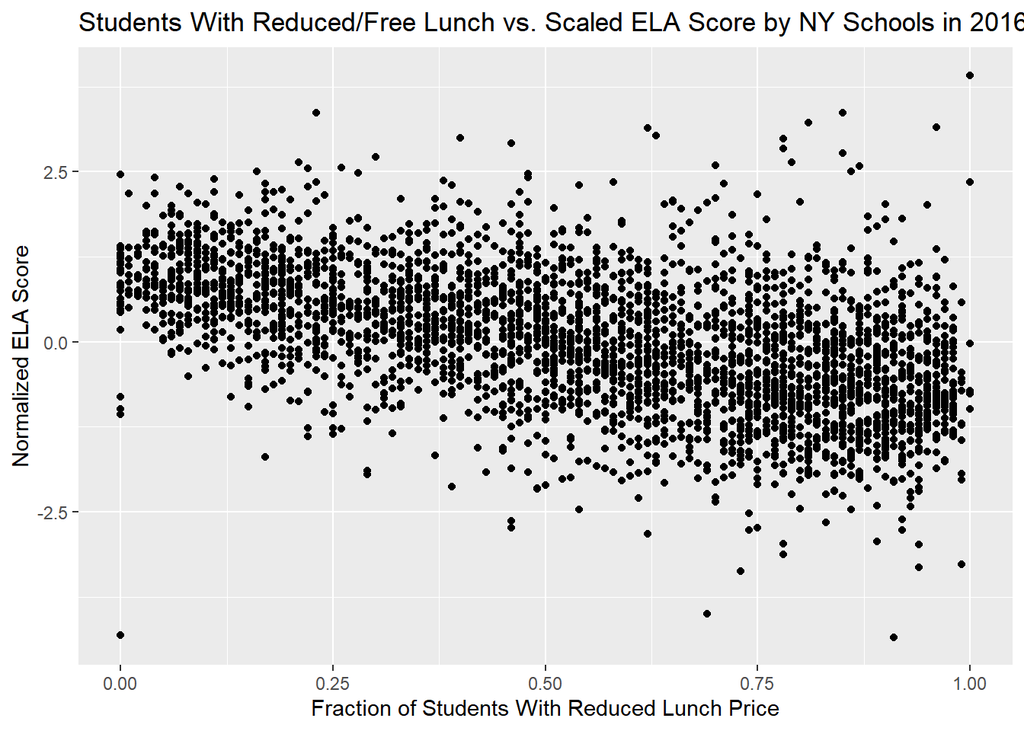

```r
library(ggplot2)

#Free/reduced price lunch vs. test scores graphs
ggplot(schools_dt[year=="2016"]) + geom_point(aes(per_free_lunch+per_reduced_lunch, scaled_ela_score)) + labs(title = "Students With Reduced/Free Lunch vs. Scaled ELA Score by NY Schools in 2016", x="Fraction of Students With Reduced Lunch Price", y="Normalized ELA Score")
```

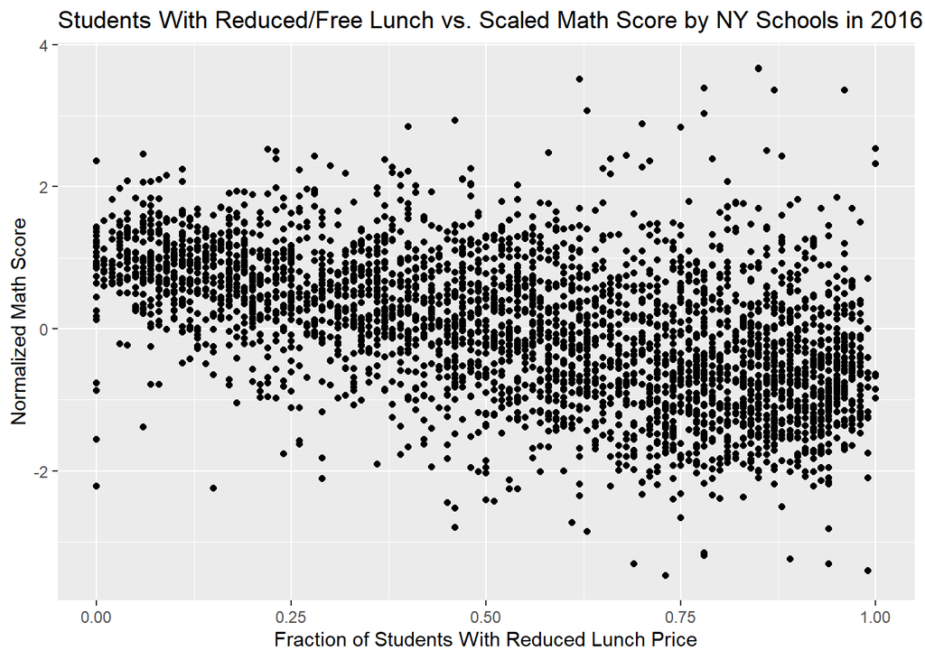

```r
ggplot(schools_dt[year=="2016"]) + geom_point(aes(per_free_lunch+per_reduced_lunch, scaled_math_score)) + labs(title = "Students With Reduced/Free Lunch vs. Scaled Math Score by NY Schools in 2016", x="Fraction of Students With Reduced Lunch Price", y="Normalized Math Score")
```

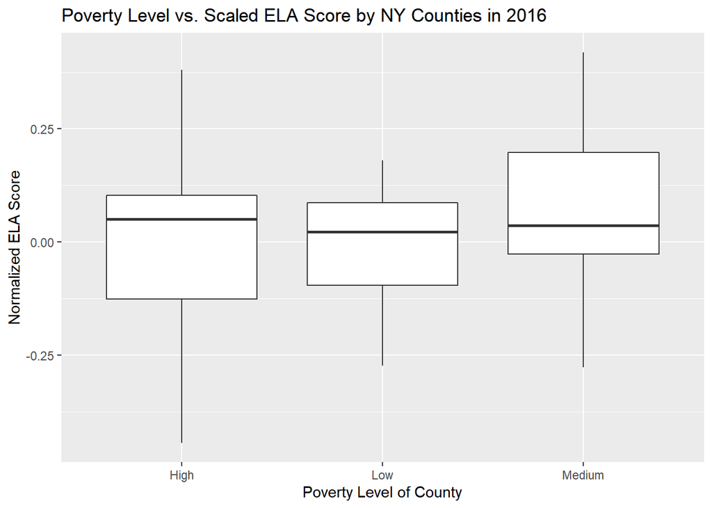

```r
#test scores across counties by poverty level
ggplot(merged_dt[year=="2016"]) + geom_boxplot(aes(poverty_level, median_ela_score)) + labs(title = "Poverty Level vs. Scaled ELA Score by NY Counties in 2016", x="Poverty Level of County", y="Normalized ELA Score")
```

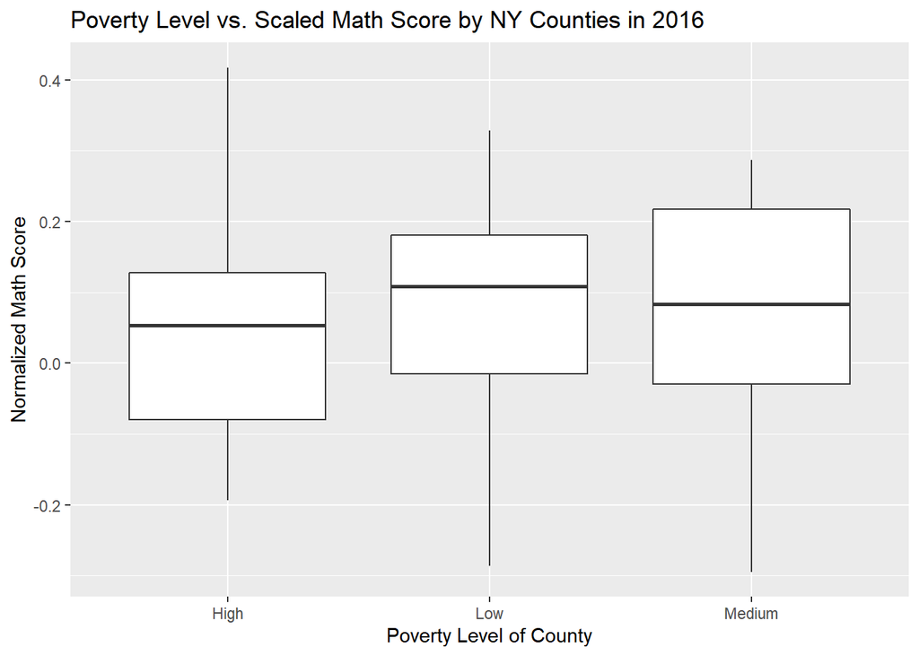

```r
ggplot(merged_dt[year=="2016"]) + geom_boxplot(aes(poverty_level, median_math_score)) + labs(title = "Poverty Level vs. Scaled Math Score by NY Counties in 2016", x="Poverty Level of County", y="Normalized Math Score")
```

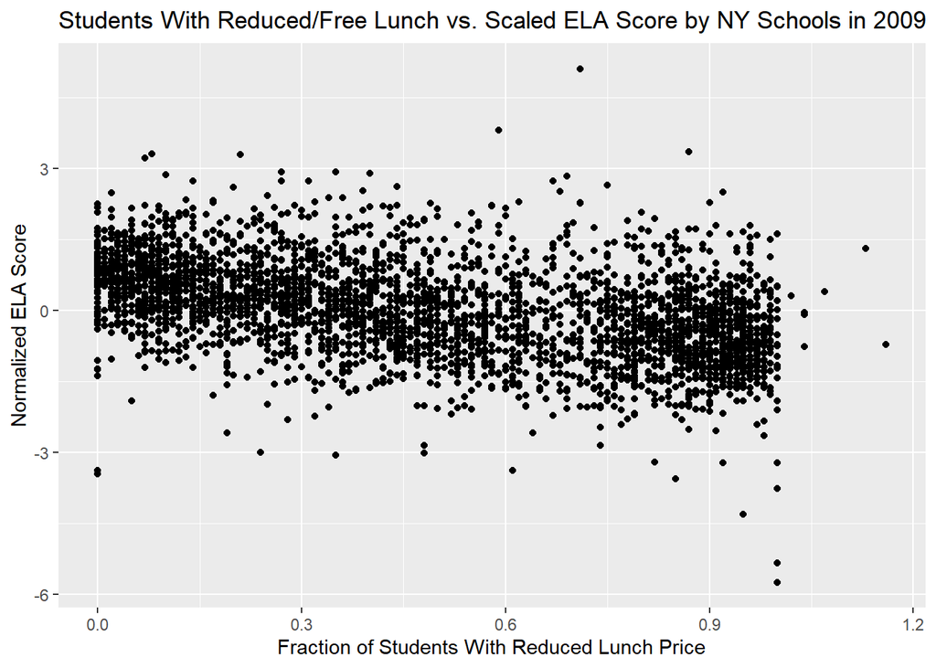

```r
#Free/reduced price lunch vs. test scores graphs
ggplot(schools_dt[year=="2009"]) + geom_point(aes(per_free_lunch+per_reduced_lunch, scaled_ela_score)) + labs(title = "Students With Reduced/Free Lunch vs. Scaled ELA Score by NY Schools in 2009", x="Fraction of Students With Reduced Lunch Price", y="Normalized ELA Score")
```

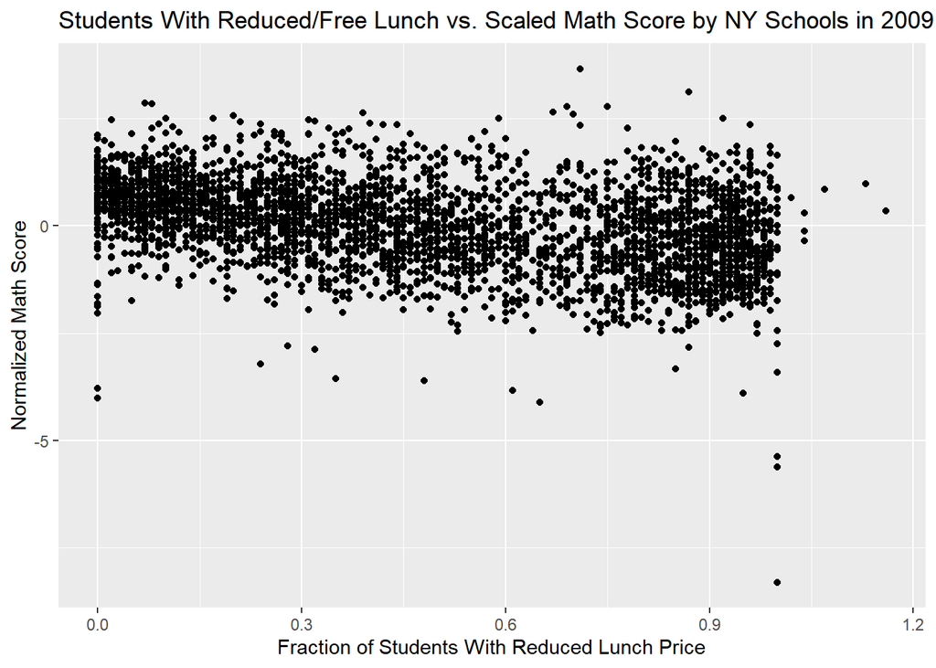

```r
ggplot(schools_dt[year=="2009"]) + geom_point(aes(per_free_lunch+per_reduced_lunch, scaled_math_score)) + labs(title = "Students With Reduced/Free Lunch vs. Scaled Math Score by NY Schools in 2009", x="Fraction of Students With Reduced Lunch Price", y="Normalized Math Score")
```

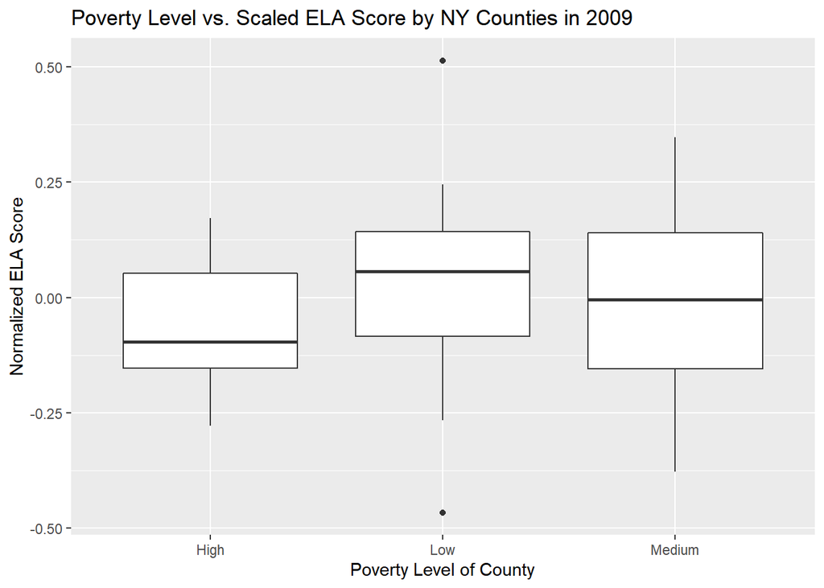

```r
#test scores across counties by poverty level
ggplot(merged_dt[year=="2009"]) + geom_boxplot(aes(poverty_level, median_ela_score)) + labs(title = "Poverty Level vs. Scaled ELA Score by NY Counties in 2009", x="Poverty Level of County", y="Normalized ELA Score")
```

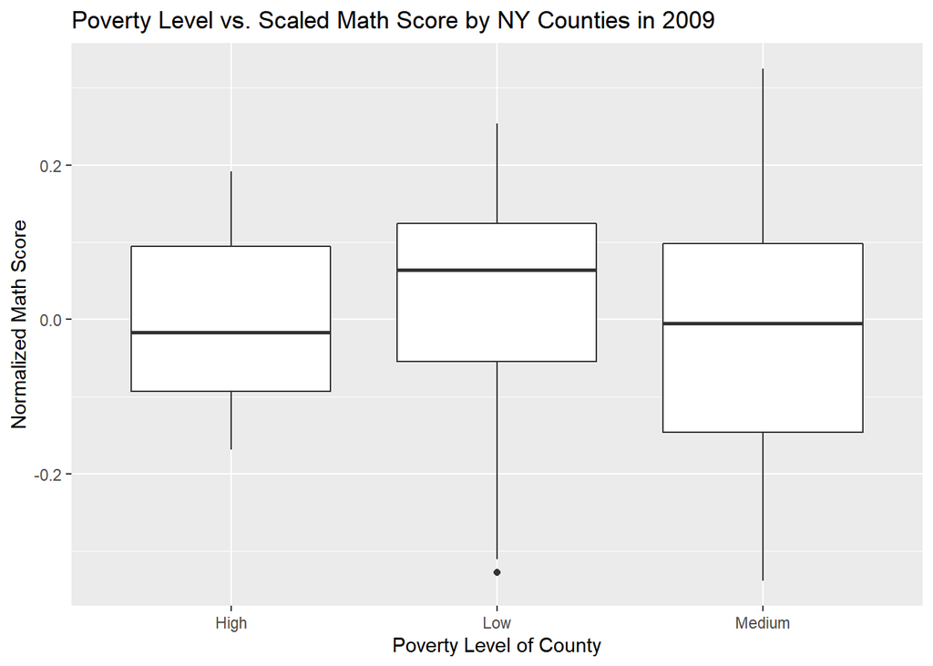

```r
ggplot(merged_dt[year=="2009"]) + geom_boxplot(aes(poverty_level, median_math_score)) + labs(title = "Poverty Level vs. Scaled Math Score by NY Counties in 2009", x="Poverty Level of County", y="Normalized Math Score")
```

## 7. Final Questions

1. What is the relationship between poverty and test performance in New York public schools?

There appears to be a relationship between poverty and test performance in New York schools. Specifically, for math scores, the boxplots above shows a lower average score in both 2009 and 2016 for high poverty counties compared to low poverty counties. Medium poverty areas have math scores fall in the middle of the two, showing there is a negative correlation between county poverty level and math test scores. A similar trend can be seen for English-Language Arts (ELA) test scores in 2009. But, what is interesting is the test scores for ELA are similar across the board in 2016. High poverty areas have a wider range of outcomes and medium poverty areas may be slightly better than the other two groups, but it is worth more analysis to see why low poverty areas have similar ELA scores in this year.

2. Does access do reduced price lunch impact test scores in any way? The scatter plots above show the relationship between the fraction of students with reduced lunch prices vs. math and ELA test scores in both 2009 and 2016. All of these relationships show a negative correlation between access to reduced lunch prices and test scores no matter the year nor test subject. This does not mean that giving students access to cheap lunch makes them worse at test taking, but is more likely an indication of the poverty level at the respective schools with more students requiring free lunch in high poverty areas. This conclusion aligns with the findings from the first research question above. Further analysis should be done to isolate high poverty schools that have access to reduced price lunch and compare their test scores to high poverty schools without access to reduced price lunch to see if there is a difference between groups. This would be a better indicator of whether reducing lunch price improves test scores for children in poverty.
3. Has this relationship between poverty and test scores changed over time? It appears this relationship has changed over time. Looking again at the boxplots, we can see both the median math and ELA test score in 2009 for high poverty counties was below average (below 0.0). In 2016, the median for both test scores has jumped to above average for high poverty areas, essentially getting closer to evening the playing field between schools in high and low poverty areas. This is a promising trend. The reasons for this could be related to greater access to free lunches, but further analysis would need to be completed to paint a clear picture of the trend over time as well as the drivers of increased test scores.